# Converting continuous trait regression coefficient to an OR

This code attempts to implement a method for converting an linear regression coefficient to and Odds Ratio

## Simulation setup

```r
library(ggplot2)
set.seed(666)
N<-1000
maf<-0.1
beta<-0.4
p.val<-5e-8
beta.se<-beta/abs(qnorm(p.val/2))
```

Here we simulate a continuous trait with slope $\beta=$ 0.4 in a sample size of $N=$ 1000 in a single biallelic SNP with maf$=$ 0.1 at a significance of $P=$ 510^{-8}. This implies a $\sigma_{\beta}=$ 0.0733769.

```r
#simulate genotypes
X<-rbinom(N,2,maf)
Xbar<-mean(X)
se.e<-beta.se * sqrt(sum((X-Xbar)^2))
#simulate y for a given beta and s
Y=X*beta+rnorm(N,mean=0,sd=se.e)
```

## Plot data with Fit

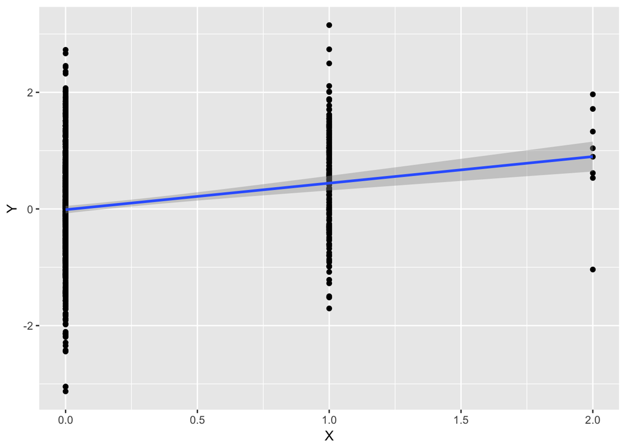

```r
ggplot(data.frame(x=X,y=Y),aes(x=X,y=Y)) + geom_point()  + geom_smooth(method='lm',formula=y~x)
```

## Coefficients of the linear model

```r
mod<-lm(Y~X)
summary(mod)
```

```
##
## Call:
## lm(formula = Y ~ X)
##
## Residuals:
##      Min       1Q   Median       3Q      Max
## -3.11516 -0.64422  0.03306  0.63959  2.74124
##
## Coefficients:
##             Estimate Std. Error t value Pr(>|t|)
## (Intercept) -0.01248    0.03275  -0.381    0.703
## X            0.45516    0.07063   6.444 1.81e-10 ***
## ---
## Signif. codes:  0 '***' 0.001 '**' 0.01 '*' 0.05 '.' 0.1 ' ' 1
##
## Residual standard error: 0.9355 on 998 degrees of freedom
## Multiple R-squared:  0.03995,    Adjusted R-squared:  0.03898
## F-statistic: 41.52 on 1 and 998 DF,  p-value: 1.809e-10
```

## Coefficients for the logistic model

```r
Yb<-ifelse(Y>mean(Y),1,0)
lmod<-glm(Yb~X,family="binomial")
summary(lmod)
```

```
##
## Call:
## glm(formula = Yb ~ X, family = "binomial")
##
## Deviance Residuals:
##     Min       1Q   Median       3Q      Max
## -1.7744  -1.1209   0.6814   1.2350   1.2350
##
## Coefficients:
##             Estimate Std. Error z value Pr(>|z|)
## (Intercept) -0.13448    0.07027  -1.914   0.0557 .
## X            0.73829    0.16014   4.610 4.02e-06 ***
## ---
## Signif. codes:  0 '***' 0.001 '**' 0.01 '*' 0.05 '.' 0.1 ' ' 1
##
## (Dispersion parameter for binomial family taken to be 1)
##
##     Null deviance: 1386.3  on 999  degrees of freedom
## Residual deviance: 1363.8  on 998  degrees of freedom
## AIC: 1367.8
##
## Number of Fisher Scoring iterations: 4
```

## Computing log(OR) using summary stats from linear model

First estimate $\bar{x}$ using just maf, and sample size.

```r
raf<-1-maf
## Brute force
wtscore<-function(N,r,w=0) N * r^2 * w
hetscore<-function(N,r,w=1) 2 * N * r * (1-r) * w
homscore<-function(N,r,w=2) N * (1-r)^2 *w
estXbarHat<-(wtscore(N,raf) + hetscore(N,raf) + homscore(N,raf))/N
## if we do the algebra then xbarhat simplifies to 2 * (1-raf) or 2 * maf
XbarHat<-2*maf
```

Actual sample $\bar{x}$ is 0.2, from brute force 0.2 and from simplification 0.2. So far so good.

Next estimate $\bar{y}$, which I think is the value of $Y|X=\bar{x}$ or $\hat{y} = \beta \bar{x}$

```r
YbarHat<-beta * XbarHat
```

Actual sample $\bar{y}$ is 0.078 our estimate is 0.08.

Next we want to estimate the sum of squares for X (SSX) or $\sum_i (X_i-\bar{x})^2$

```r
n.wt<-wtscore(N,raf,1)
SSX.wt<-sum(n.wt * XbarHat^2)
n.het<-hetscore(N,raf,1)
SSX.het<-sum((rep(1,n.het)-rep(XbarHat,n.het))^2)
n.hom<-homscore(N,raf,1)
SSX.hom<-sum((rep(2,n.hom)-rep(XbarHat,n.hom))^2)
SSXHat=SSX.wt + SSX.het + SSX.hom
```

Actual sample SSX is 175.399 estimate is 176.12. Looking good !

Next compute $\hat{\sigma_{\epsilon}}$ that is our estimate of the standard error for $\epsilon$. We compute this using the the given value of $\sigma_{\beta}$. As we know that $\sigma_{\epsilon} = \sigma_{\beta} \times \sqrt{\sum_i (X_i-\bar{x})^2}$. We have estimated SSX above and so have all we need.

```r
se.eHat<-beta.se * sqrt(SSXHat)
```

The actual value of $\sigma_{\epsilon}$ is 0.97 our estimated value is 0.97. Looking good !

Next we need to estimate the Odds of $(Y>\bar{y} | X = x)$ we can then compute the OR as $\frac{Odds(Y>\bar{y} | X = 1)}{Odds(Y>\bar{y} | X = 0)}$

```r
## next estimate P(Y>ybar | X =x)
calcOdds<-function(X,beta,SE.epsilon,val=YbarHat){
    num<-pnorm(val,mean=X*beta,sd=SE.epsilon,lower.tail = FALSE)
    num/(1-num)
}

lod_Y_X1<-log(calcOdds(1,beta,se.eHat))
lod_Y_X0<-log(calcOdds(0,beta,se.eHat))

lodHat<-lod_Y_X1-lod_Y_X0
## get estimated log(OR) from fit
fitLod<-summary(lmod)[["coefficients"]][,1][2]
```

Actual log(OR) from logistic regression fit is 0.74 our estimate is 0.66.